# project_2_eda

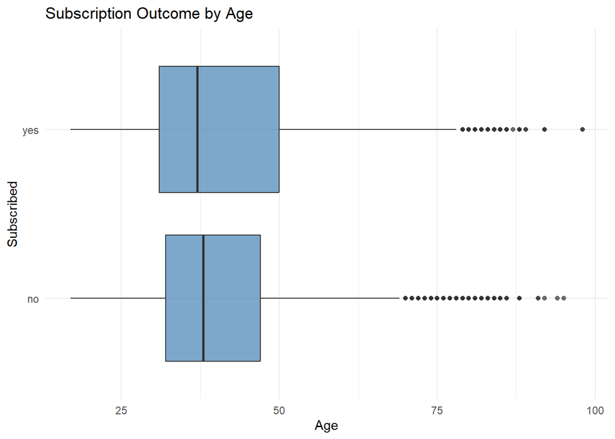

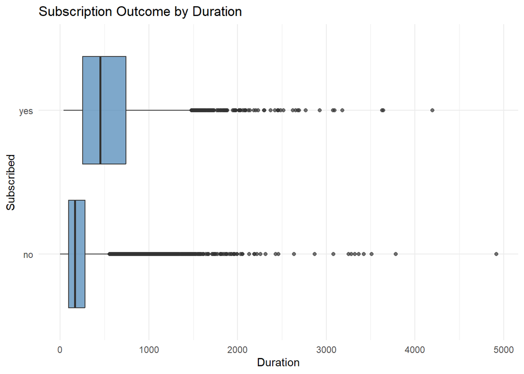

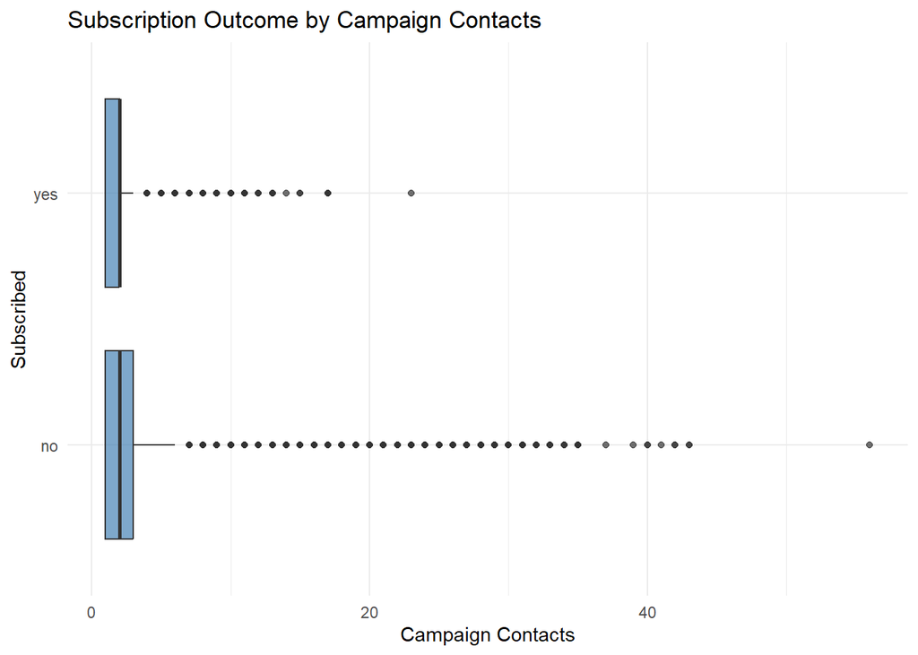

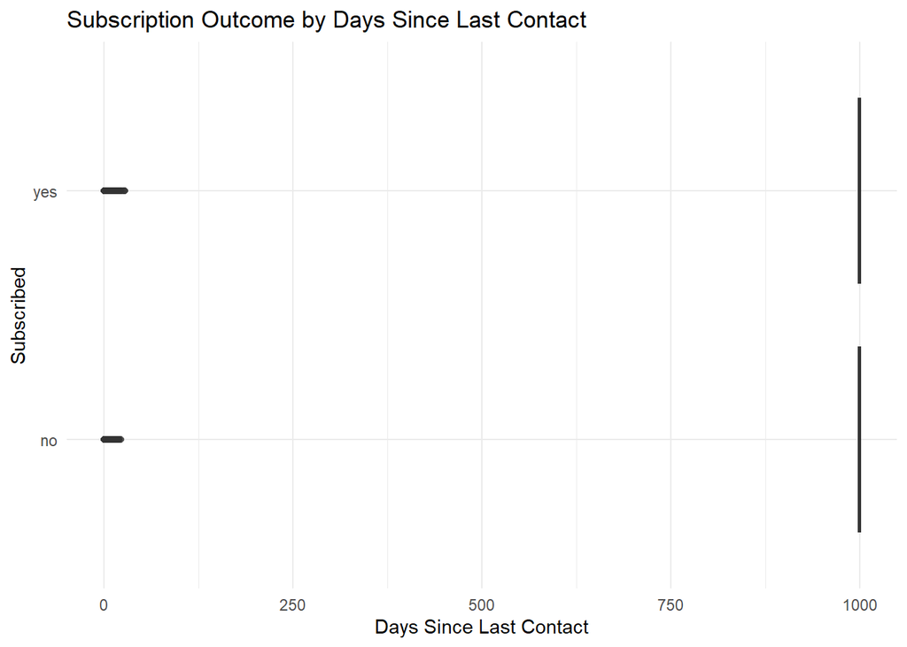

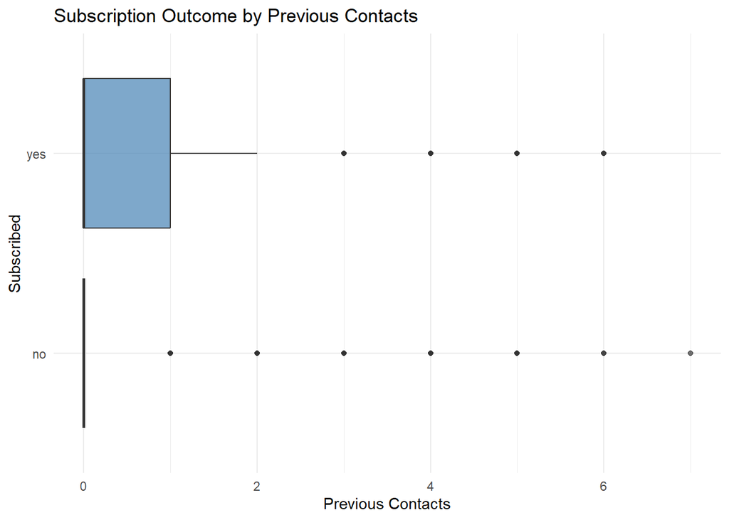

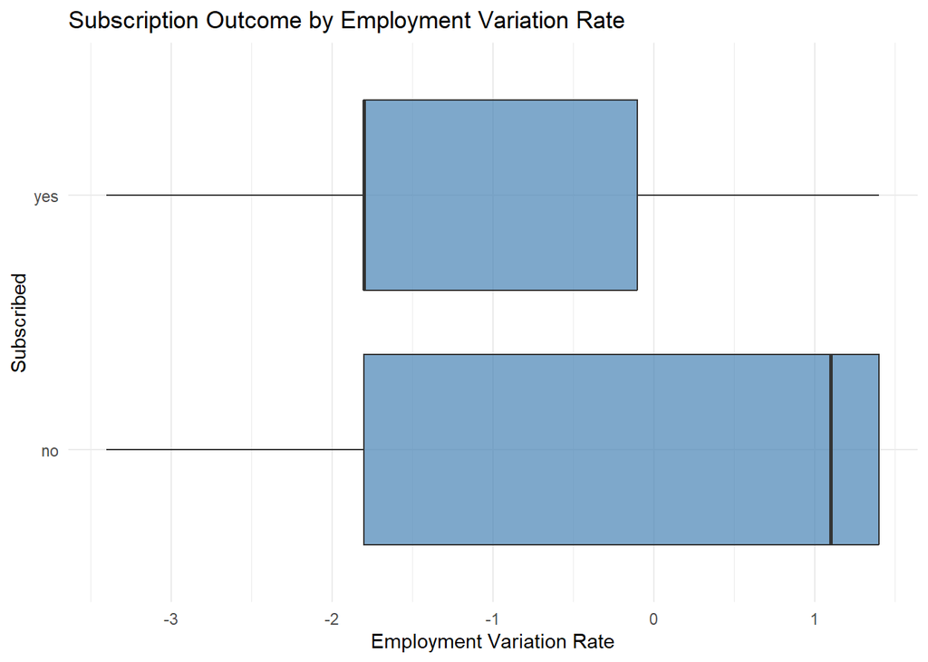

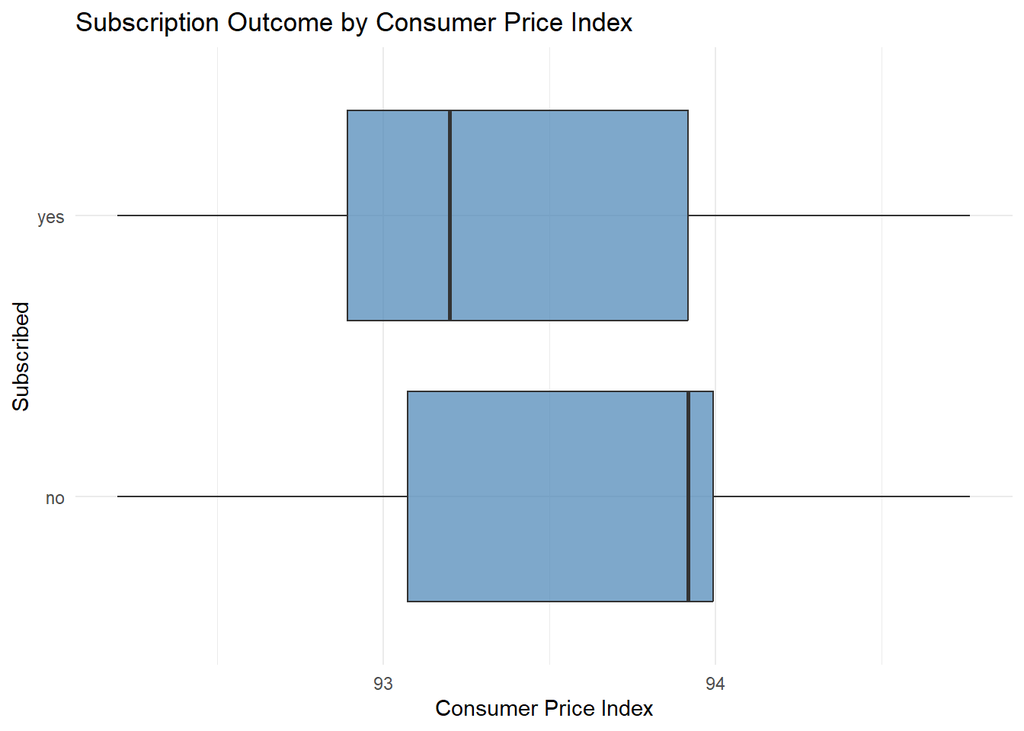

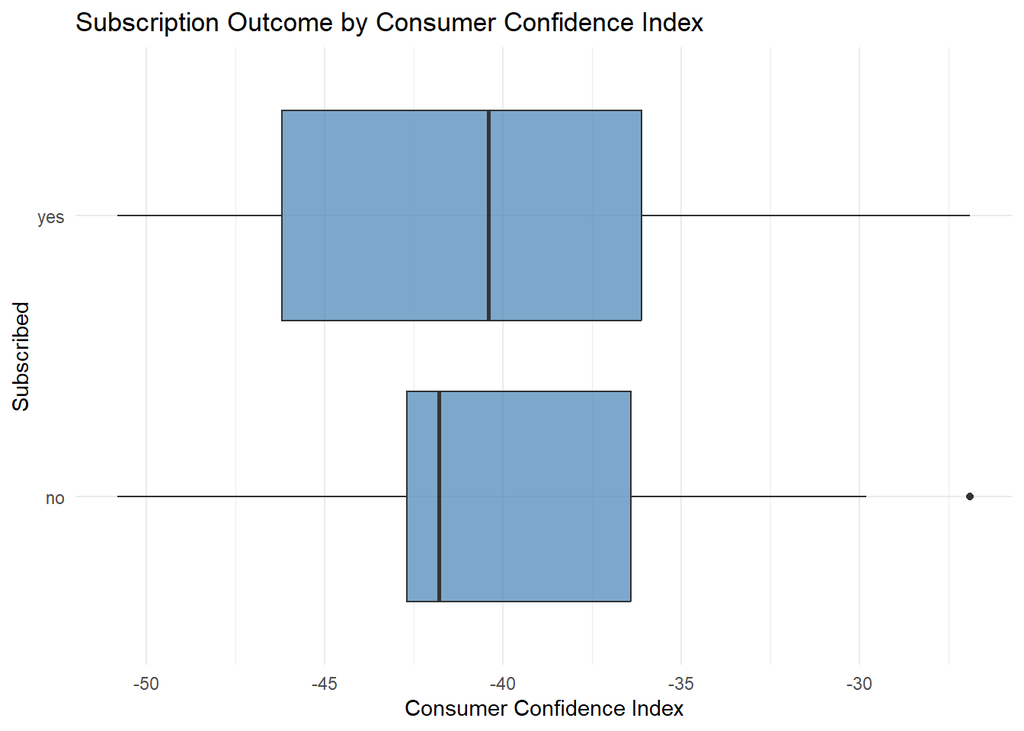

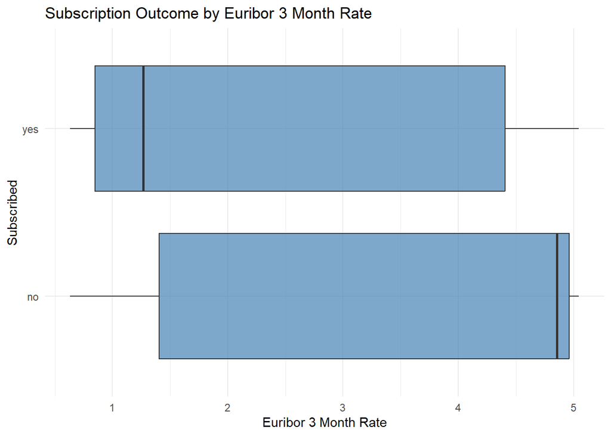

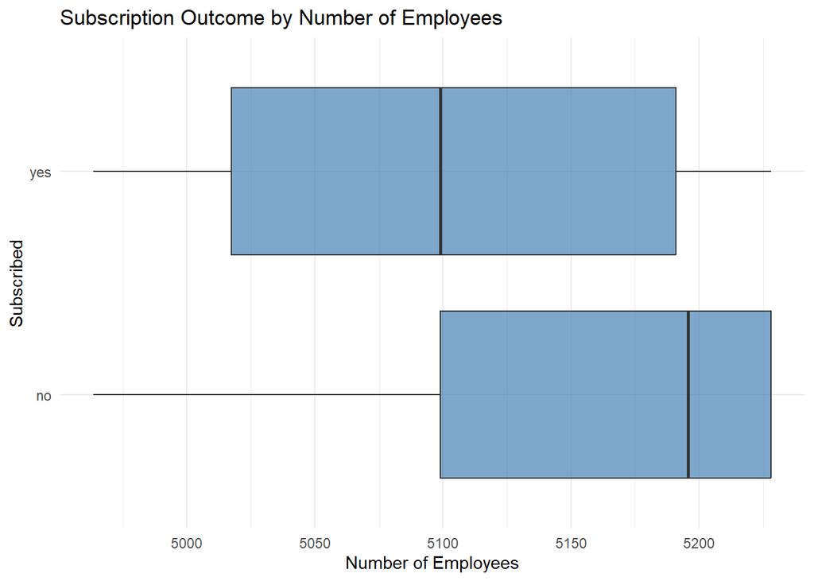

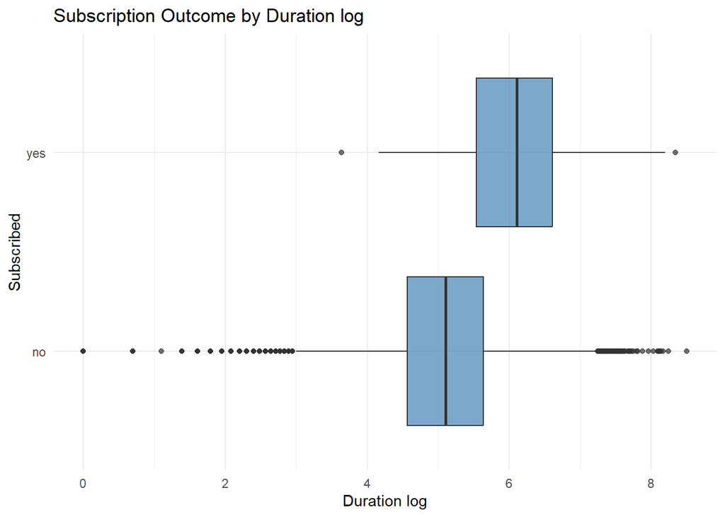

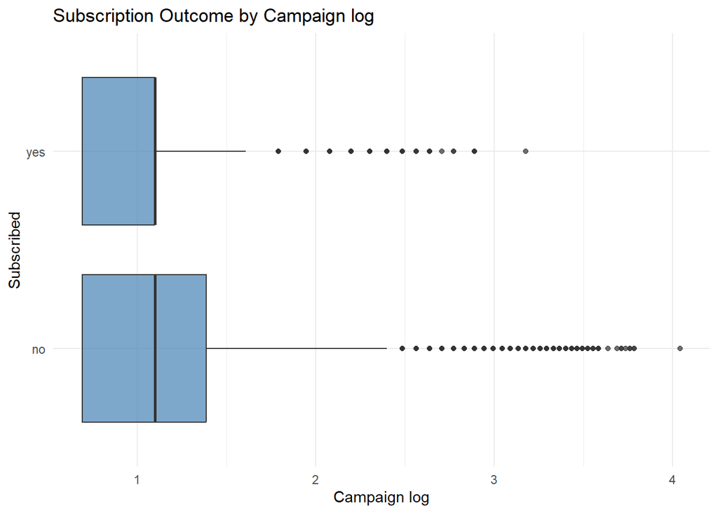

```r
for (var in num_vars) {
  p = ggplot(df, aes(x = !!sym(var), y = y)) +
    geom_boxplot(aes(group = y), fill = "steelblue", alpha = 0.7) +
    labs(
      x = get_label(var),
      y = "Subscribed",
      title = paste("Subscription Outcome by", get_label(var))
    ) +
    theme_minimal()
  print(p)
}
```

We note that the log of duration is much higher among subscribers, which makes intuitive sense. As noted previously, this is not useful for predictive modeling, but it may be useful for interpretive modeling.

### Subscriptions by Categorical Predictors

**Click to expand: Categorical Bivariate Plots**

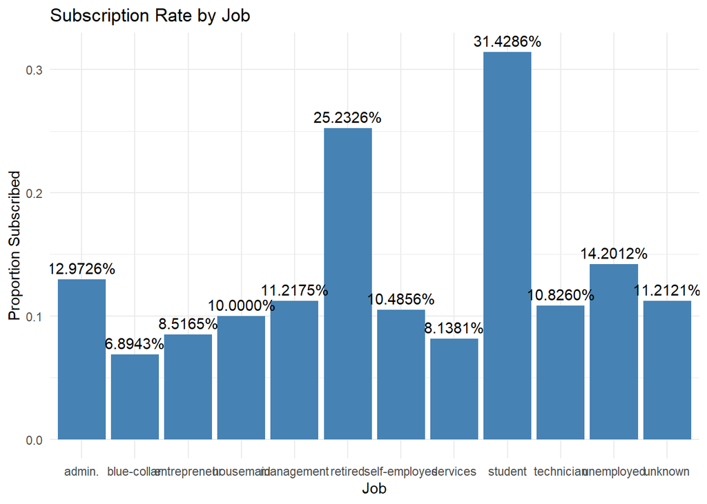

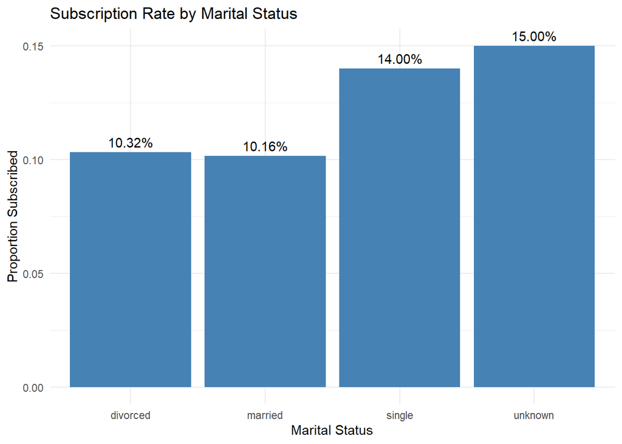

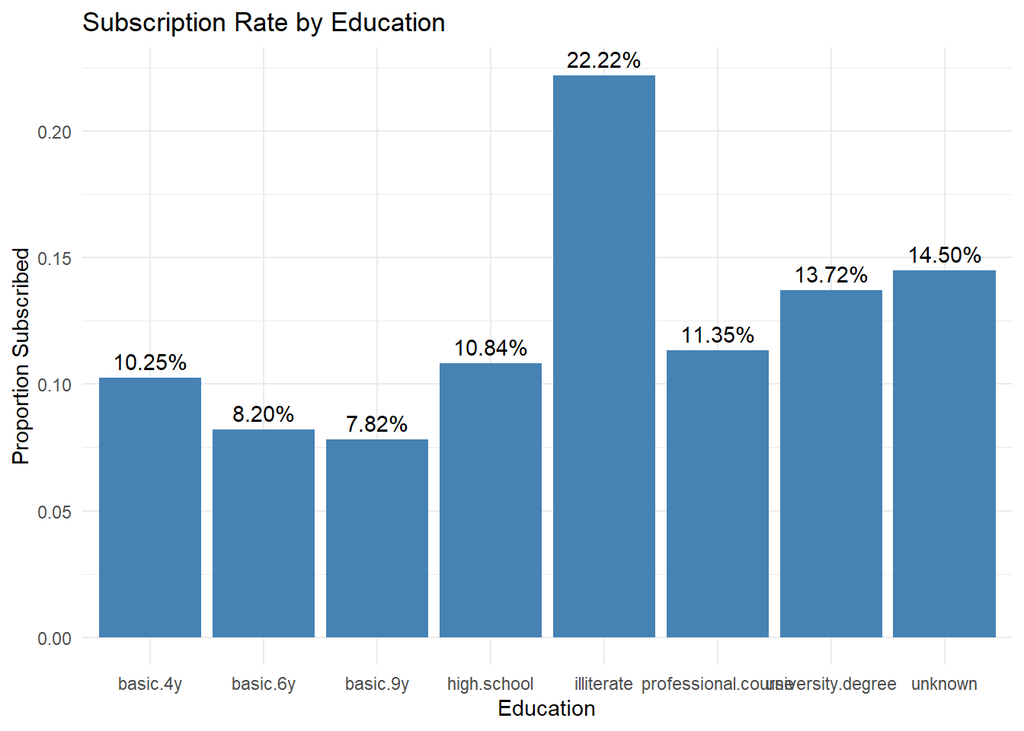

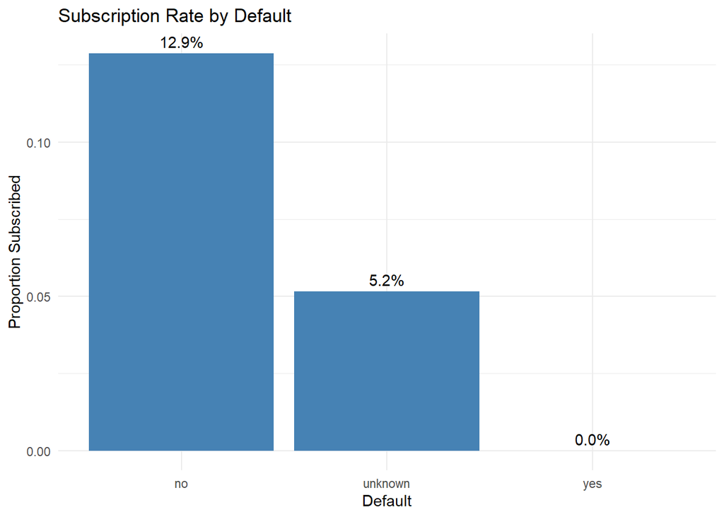

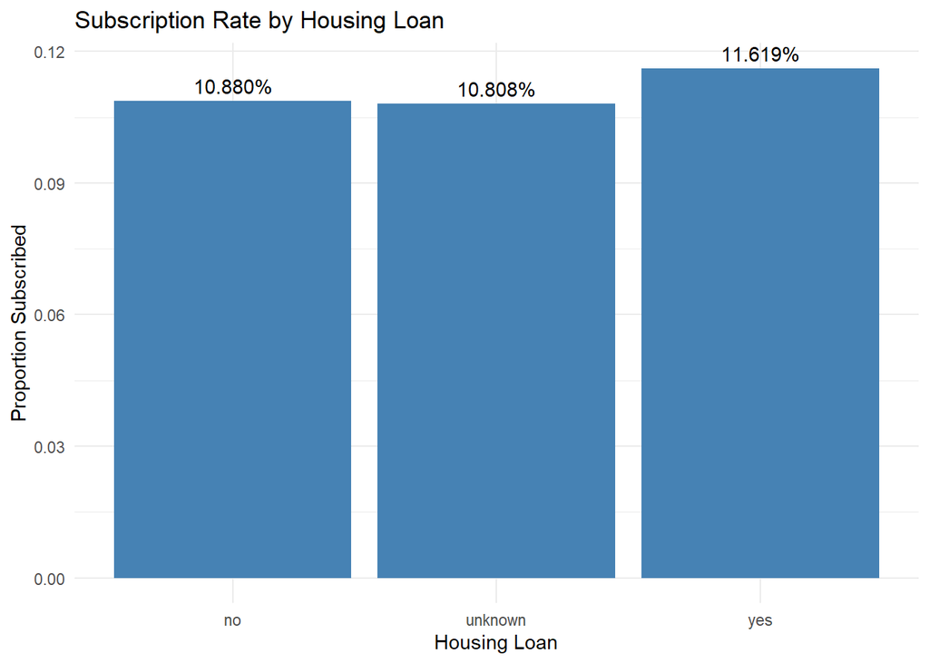

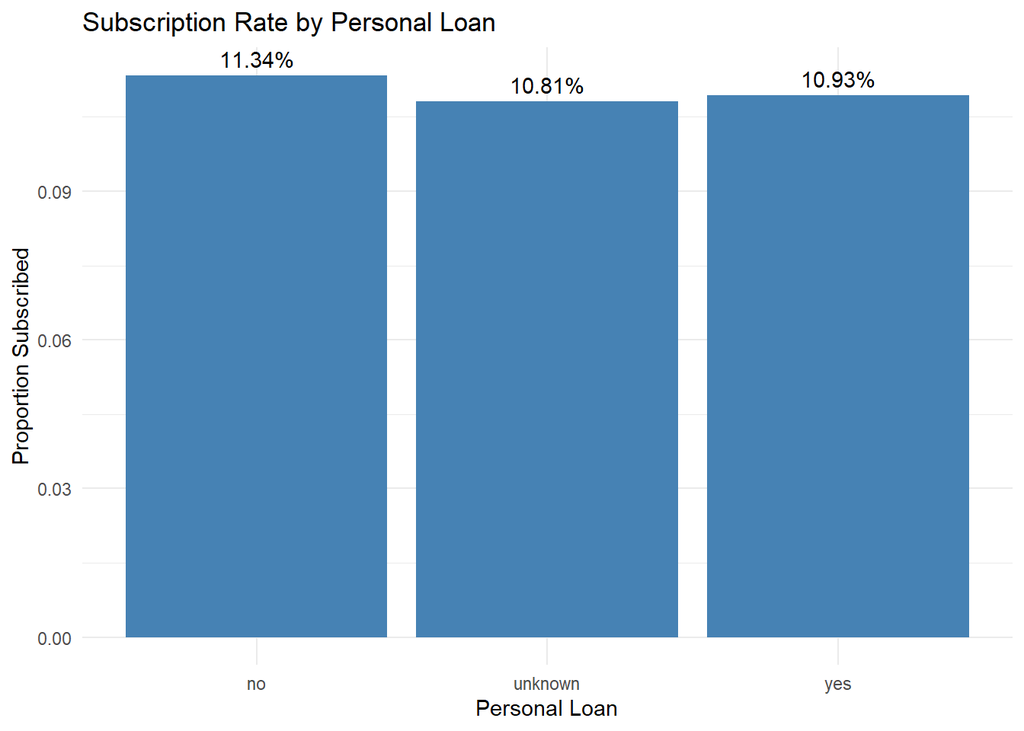

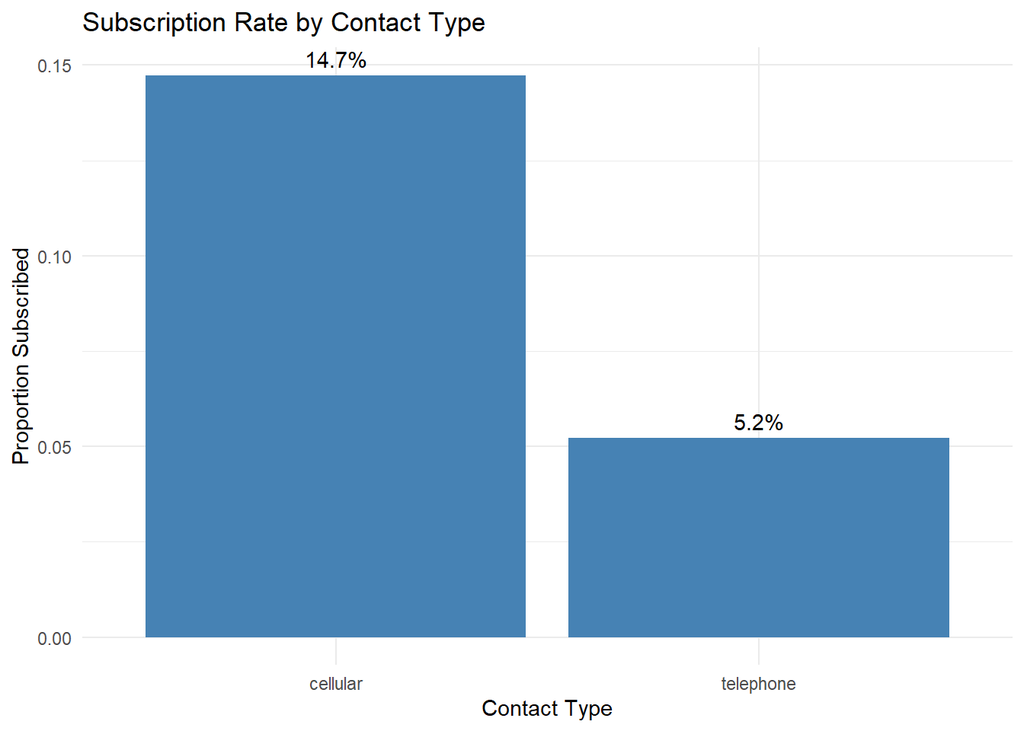

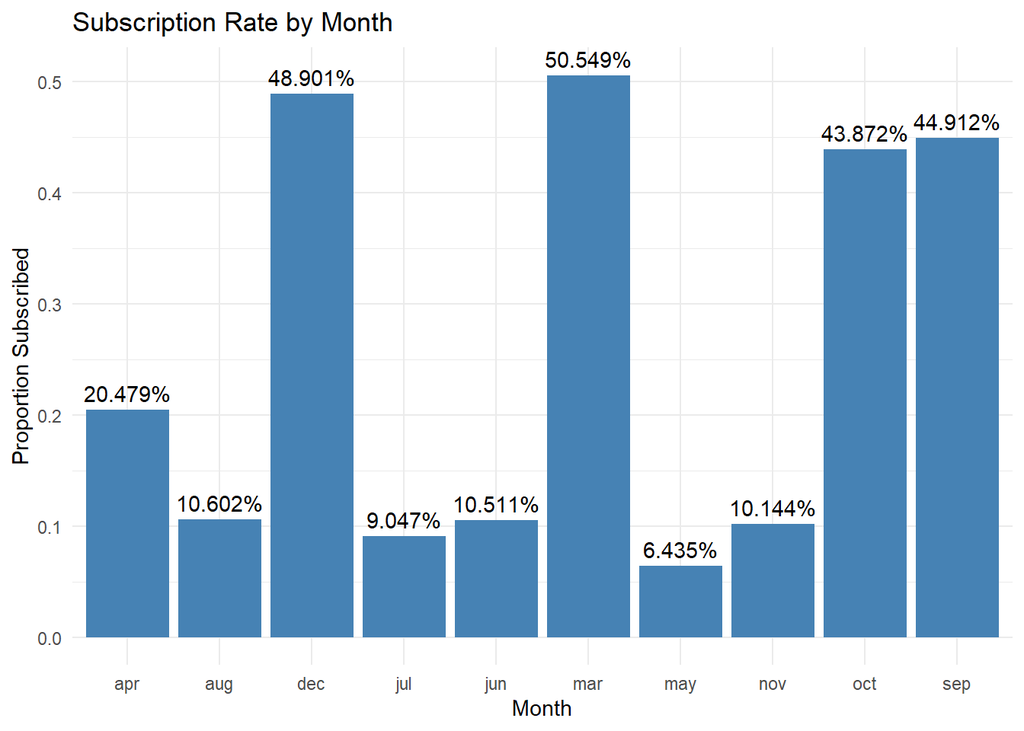

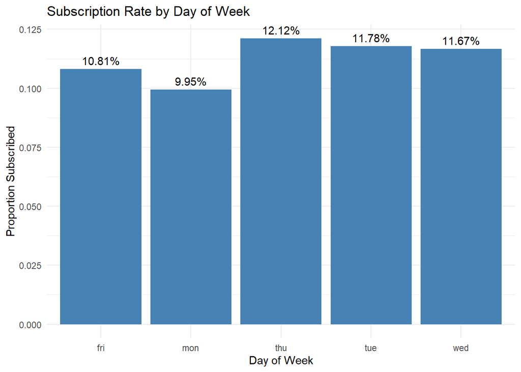

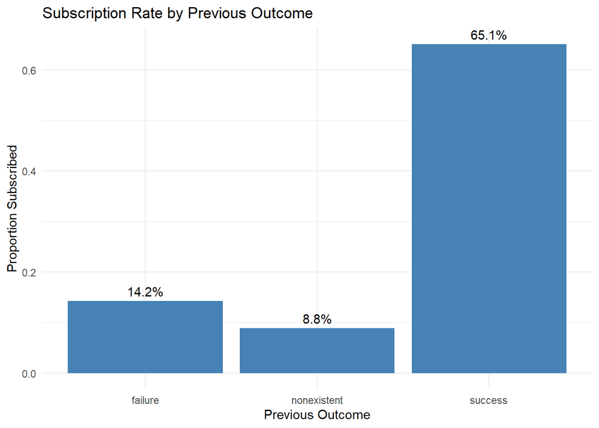

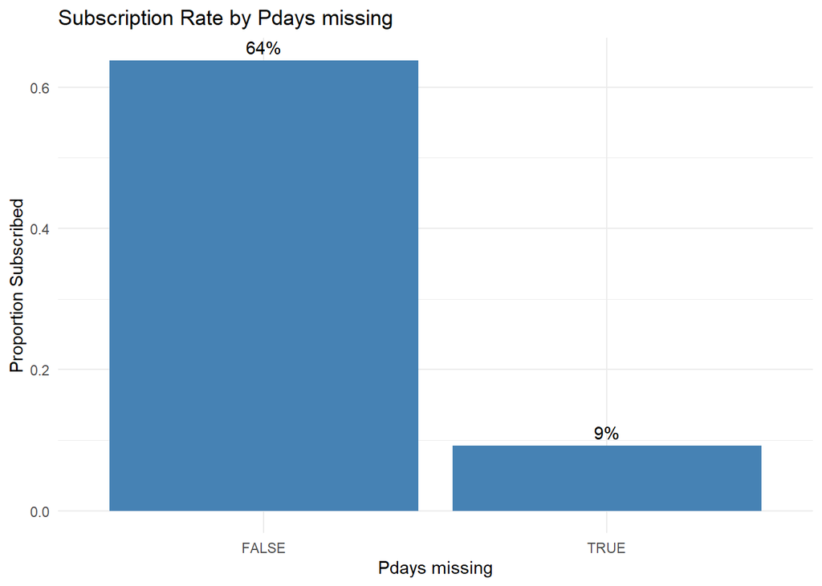

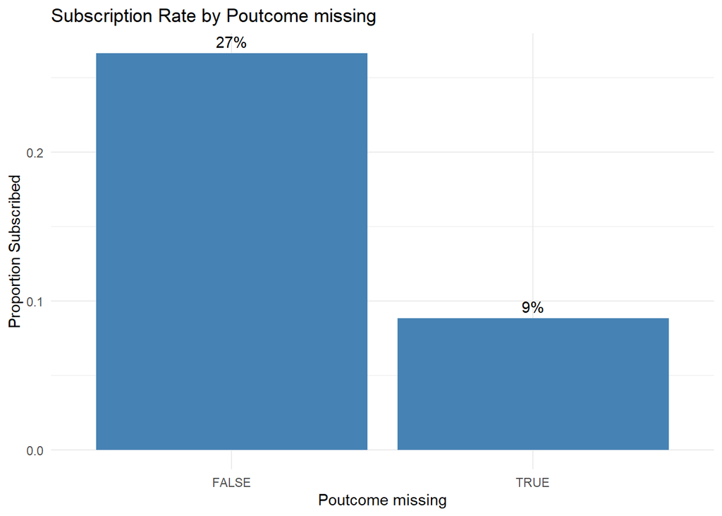

[3 more figures not shown]

```r
for (var in cat_vars) {
  p = df %>%
    group_by(!!sym(var)) %>%
    summarise(prop_yes = mean(y == "yes")) %>%
    ggplot(aes(x = !!sym(var), y = prop_yes)) +
    geom_col(fill = "steelblue") +
    geom_text(aes(label = scales::percent(prop_yes)), vjust = -0.5) +
    labs(
      x = get_label(var),
      y = "Proportion Subscribed",
      title = paste("Subscription Rate by", get_label(var))
    ) +
    theme_minimal()
  print(p)
}
```

Clients with prior campaign contact (pdays_missing = FALSE) and a recorded previous outcome (poutcome ≠ unknown) are substantially more likely to subscribe. Due to overlap in what they convey, we may choose to retain only one: poutcome captures both the presence and outcome of prior engagement.

Binning the number of previous and current campaign contacts revealed clearer patterns. Subscription rates were much lower among clients with no prior contacts, and current campaign contact counts show a declining trend, hinting at diminishing returns from repeated contact.

We also see that the Euribor 3-Month Rate binned variable has a strong relationship with the response variable, with rates at either extreme having a high subscription rate. This suggests that the economic conditions at the time of the marketing campaign may be a useful predictor.

As noted previously, the default variable has very few “yes” values, and the housing and loan variables also show very similar rates for all levels. These seem to have little explanatory power, and we may consider dropping them from the model.

### Multicollinearity Check

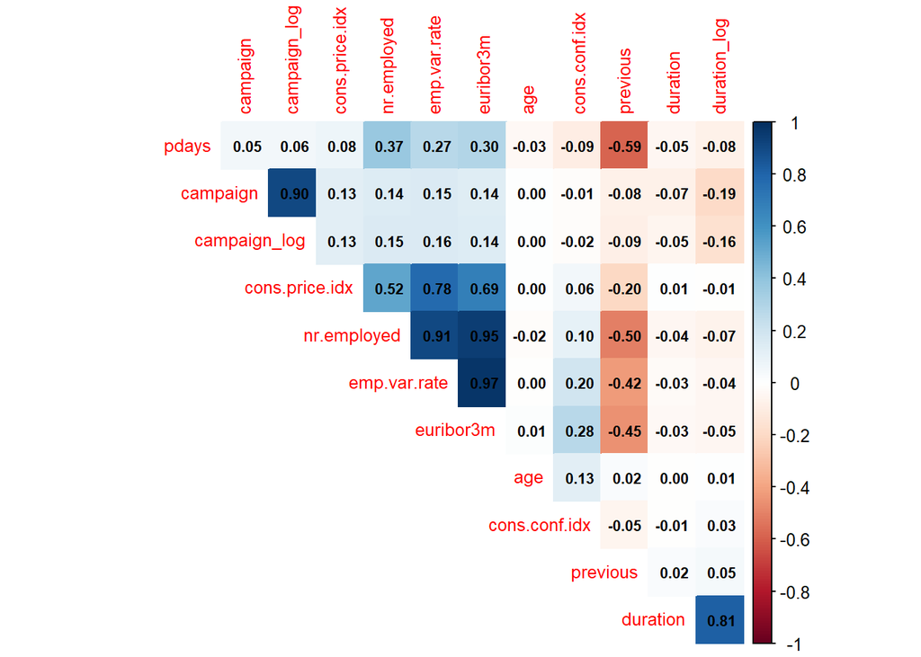

```r
cor_data = df %>% select(all_of(num_vars))

cor_matrix = cor(cor_data, use = "complete.obs")

corrplot(cor_matrix,
         method = "color",
         type = "upper",
         order = "hclust",
         addCoef.col = "black",
         tl.cex = 0.8,
         number.cex = 0.7,
         diag = FALSE)
```

The correlation matrix shows that there is high collinearlity among our macroeconomic predictors: Euribor is highly collinear with employment, and consumer price index is moderately correlated with both of those predictors.

```r
eda_vif_model = glm(
  y ~ age + emp.var.rate + cons.price.idx + cons.conf.idx +
      euribor3m + nr.employed + duration_log + campaign_log,
  data = df,
  family = binomial
)
vif(eda_vif_model)
```

```
##            age   emp.var.rate cons.price.idx  cons.conf.idx      euribor3m
##       1.032363      34.352996      10.884336       3.065015      63.534716
##    nr.employed   duration_log   campaign_log
##      36.831966       1.251581       1.035402
```

A VIF analysis confirms that the employment variation rate, consumer price index, and Euribor 3-Month Rate have high VIF values, indicating multicollinearity.

# 3: Interpretive Model

## Data Preparation

```r
set.seed(1234)
train_proportion = 0.7
train_indices = sample(1:nrow(df), size = floor(train_proportion * nrow(df)))
train_df = df[train_indices, ]
```

## Feature Selection Considerations

Based on exploratory data analysis, we find that duration_log, campaign_log, cons.conf.idx, euribor3m, contact, month, poutcome, job, and education are potentially useful predictors in fitting an interpretive model.

The campaign_bin transformation may be more useful than the log-transformed version, as it captures the diminishing returns of repeated contacts. This is an open question, and we will test both versions in the model.

Euribor 3-Month Rate is highly collinear with employment variation rate and consumer price index, so we will need to choose one of these macroeconomic predictors to include in the model. Euribor has a more direct relationship with the response in our EDA, so we will include it in the model.

There is a decision to make as to whether we prefer the binned or continuous version of euribor3m. The relationship between the binned version and the response variable is clearer in the EDA, and more interpetable, so we will use it in the interpretive model, but the numeric version may be more appropriate for the predictive model.

Given the data quality issues surrounding the original pdays variable, and its redundancy with poutcome, we will not include it in the model. Instead, we will use poutcome, which offers more detailed information about prior marketing attempts without the data quality issues. We will not include the raw or binned version of previous contacts to avoid overlap, since poutcome is more informative and interpretable.

```r
# num_vars
# cat_vars
```

## Baseline Model (All Predictors, No Transformations)

```r
baseline_model_raw = glm(
  y ~ age + duration + campaign + pdays + previous +
      emp.var.rate + cons.price.idx + cons.conf.idx + euribor3m + nr.employed +
      job + marital + education + default + housing + loan +
      contact + month + day_of_week + poutcome,
  data = train_df,
  family = binomial
)

summary(baseline_model_raw)
```

```
##
## Call:
## glm(formula = y ~ age + duration + campaign + pdays + previous +
##     emp.var.rate + cons.price.idx + cons.conf.idx + euribor3m +
##     nr.employed + job + marital + education + default + housing +
##     loan + contact + month + day_of_week + poutcome, family = binomial,
##     data = train_df)
##
## Coefficients: (1 not defined because of singularities)
##                                Estimate Std. Error z value Pr(>|z|)
## (Intercept)                  -2.347e+02  4.608e+01  -5.092 3.53e-07 ***
## age                           1.736e-03  2.940e-03   0.591 0.554849
## duration                      4.782e-03  9.023e-05  52.992  < 2e-16 ***
## campaign                     -2.685e-02  1.395e-02  -1.925 0.054261 .
## pdays                        -6.411e-04  2.656e-04  -2.414 0.015766 *
## previous                     -8.901e-02  7.136e-02  -1.247 0.212276
## emp.var.rate                 -1.861e+00  1.716e-01 -10.845  < 2e-16 ***
## cons.price.idx                2.236e+00  3.040e-01   7.355 1.90e-13 ***
## cons.conf.idx                 1.916e-02  9.331e-03   2.054 0.039992 *
## euribor3m                     4.781e-01  1.569e-01   3.047 0.002313 **
## nr.employed                   4.034e-03  3.745e-03   1.077 0.281501
## jobblue-collar               -1.934e-01  9.637e-02  -2.007 0.044801 *
## jobentrepreneur              -5.937e-02  1.459e-01  -0.407 0.684090
## jobhousemaid                  1.211e-01  1.762e-01   0.687 0.491803
## jobmanagement                -3.906e-02  1.029e-01  -0.380 0.704272
## jobretired                    3.607e-01  1.280e-01   2.818 0.004832 **
## jobself-employed             -1.836e-01  1.451e-01  -1.265 0.205774
## jobservices                  -6.588e-02  1.041e-01  -0.633 0.526735
## jobstudent                    2.795e-01  1.345e-01   2.078 0.037724 *
## jobtechnician                 1.028e-02  8.640e-02   0.119 0.905277
## jobunemployed                -7.384e-02  1.580e-01  -0.467 0.640153
## jobunknown                    1.913e-01  2.666e-01   0.717 0.473097
## maritalmarried               -1.531e-02  8.179e-02  -0.187 0.851488
## maritalsingle                 5.262e-02  9.419e-02   0.559 0.576396
## maritalunknown                1.219e-02  4.521e-01   0.027 0.978491
## educationbasic.6y             1.400e-02  1.479e-01   0.095 0.924553
## educationbasic.9y             1.211e-02  1.146e-01   0.106 0.915819
## educationhigh.school          2.925e-02  1.105e-01   0.265 0.791181
## educationilliterate           1.100e+00  9.070e-01   1.213 0.225257
## educationprofessional.course  1.307e-01  1.216e-01   1.075 0.282267
```

[output cut: 19 more lines]

```
## day_of_weekthu                7.739e-02  7.702e-02   1.005 0.314975
## day_of_weektue                1.131e-01  7.941e-02   1.425 0.154294
## day_of_weekwed                1.257e-01  7.955e-02   1.580 0.114106
## poutcomenonexistent           3.495e-01  1.127e-01   3.102 0.001920 **
## poutcomesuccess               1.269e+00  2.588e-01   4.902 9.48e-07 ***
## ---
## Signif. codes:  0 '***' 0.001 '**' 0.01 '*' 0.05 '.' 0.1 ' ' 1
##
## (Dispersion parameter for binomial family taken to be 1)
##
##     Null deviance: 20270  on 28830  degrees of freedom
## Residual deviance: 11797  on 28778  degrees of freedom
## AIC: 11903
##
## Number of Fisher Scoring iterations: 10
```

## Baseline Model (All Predictors, With Transformations)

```r
baseline_model = glm(
  y ~ duration_log + campaign_log + cons.conf.idx + euribor_binned +
      job + marital + education + default + housing + loan +
      contact + month + day_of_week + poutcome +
      pdays_missing + poutcome_missing + prev_contacts_binned + campaign_bin,
  data = train_df,
  family = binomial
)
summary(baseline_model)
```

```
##
## Call:
## glm(formula = y ~ duration_log + campaign_log + cons.conf.idx +
##     euribor_binned + job + marital + education + default + housing +
##     loan + contact + month + day_of_week + poutcome + pdays_missing +
##     poutcome_missing + prev_contacts_binned + campaign_bin, family = binomial,
##     data = train_df)
##
## Coefficients: (3 not defined because of singularities)
##                                Estimate Std. Error z value Pr(>|z|)
## (Intercept)                  -11.768121   0.495915 -23.730  < 2e-16 ***
## duration_log                   2.230077   0.041614  53.590  < 2e-16 ***
## campaign_log                   0.127438   0.176356   0.723 0.469915
## cons.conf.idx                  0.032448   0.007778   4.172 3.02e-05 ***
## euribor_binned1               -0.504015   0.123193  -4.091 4.29e-05 ***
## euribor_binned3              -10.662813 129.957997  -0.082 0.934608
## euribor_binned4               -2.633595   0.101489 -25.950  < 2e-16 ***
## euribor_binned5+               0.736847   0.845388   0.872 0.383422
## jobblue-collar                -0.238990   0.095771  -2.495 0.012580 *
## jobentrepreneur               -0.075543   0.144062  -0.524 0.600014
## jobhousemaid                   0.124666   0.176642   0.706 0.480340
## jobmanagement                 -0.073671   0.103621  -0.711 0.477104
## jobretired                     0.476440   0.114685   4.154 3.26e-05 ***
## jobself-employed              -0.109025   0.144677  -0.754 0.451104
## jobservices                   -0.075687   0.103637  -0.730 0.465197
## jobstudent                     0.351792   0.138157   2.546 0.010886 *
## jobtechnician                  0.009310   0.086963   0.107 0.914748
## jobunemployed                 -0.080683   0.160860  -0.502 0.615970
## jobunknown                     0.258598   0.263732   0.981 0.326823
## maritalmarried                -0.024298   0.081320  -0.299 0.765097
## maritalsingle                  0.038991   0.088773   0.439 0.660502
## maritalunknown                -0.084323   0.441558  -0.191 0.848551
## educationbasic.6y              0.047028   0.144154   0.326 0.744249
## educationbasic.9y              0.004091   0.112560   0.036 0.971008
## educationhigh.school          -0.010112   0.109700  -0.092 0.926558
## educationilliterate            1.142171   0.891500   1.281 0.200131
## educationprofessional.course   0.112705   0.121633   0.927 0.354134
## educationuniversity.degree     0.237201   0.110314   2.150 0.031537 *
## educationunknown               0.194807   0.144006   1.353 0.176131
## defaultunknown                -0.272903   0.077257  -3.532 0.000412 ***
```

[output cut: 22 more lines]

```
## poutcome_missingTRUE                 NA         NA      NA       NA
## prev_contacts_binned1         -0.045428   0.130508  -0.348 0.727777
## prev_contacts_binned2+               NA         NA      NA       NA
## campaign_bin2–3               -0.217684   0.101659  -2.141 0.032249 *
## campaign_bin4+                -0.277473   0.219078  -1.267 0.205316
## ---
## Signif. codes:  0 '***' 0.001 '**' 0.01 '*' 0.05 '.' 0.1 ' ' 1
##
## (Dispersion parameter for binomial family taken to be 1)
##
##     Null deviance: 20270  on 28830  degrees of freedom
## Residual deviance: 11296  on 28777  degrees of freedom
## AIC: 11404
##
## Number of Fisher Scoring iterations: 12
```

## Feature-Selection Models

### Log Transformation for Campaign

```r
model_campaign_log = glm(
  y ~ duration_log + campaign_log + cons.conf.idx + euribor_binned +
      contact + month + poutcome + job + education,
  data = train_df,
  family = binomial
)
summary(model_campaign_log)
```

```
##
## Call:
## glm(formula = y ~ duration_log + campaign_log + cons.conf.idx +
##     euribor_binned + contact + month + poutcome + job + education,
##     family = binomial, data = train_df)
##
## Coefficients:
##                                Estimate Std. Error z value Pr(>|z|)
## (Intercept)                  -12.454739   0.395726 -31.473  < 2e-16 ***
## duration_log                   2.224489   0.041422  53.703  < 2e-16 ***
## campaign_log                  -0.129093   0.060795  -2.123  0.03372 *
## cons.conf.idx                  0.031255   0.007688   4.066 4.79e-05 ***
## euribor_binned1               -0.544862   0.120929  -4.506 6.62e-06 ***
## euribor_binned3              -10.660556 129.775964  -0.082  0.93453
## euribor_binned4               -2.708020   0.099009 -27.351  < 2e-16 ***
## euribor_binned5+               0.678306   0.842308   0.805  0.42065
## contacttelephone              -0.171467   0.084400  -2.032  0.04219 *
## monthaug                       0.349810   0.131329   2.664  0.00773 **
## monthdec                       0.457020   0.258453   1.768  0.07701 .
## monthjul                       0.573855   0.120610   4.758 1.96e-06 ***
## monthjun                       0.770454   0.110597   6.966 3.25e-12 ***
## monthmar                       1.872377   0.155233  12.062  < 2e-16 ***
## monthmay                      -0.619168   0.090859  -6.815 9.45e-12 ***
## monthnov                       0.612782   0.130381   4.700 2.60e-06 ***
## monthoct                       0.667937   0.159366   4.191 2.77e-05 ***
## monthsep                       0.376185   0.174285   2.158  0.03089 *
## poutcomenonexistent            0.374887   0.075942   4.937 7.95e-07 ***
## poutcomesuccess                2.012809   0.107248  18.768  < 2e-16 ***
## jobblue-collar                -0.263978   0.095105  -2.776  0.00551 **
## jobentrepreneur               -0.109705   0.143446  -0.765  0.44440
## jobhousemaid                   0.106488   0.175302   0.607  0.54355
## jobmanagement                 -0.100013   0.102568  -0.975  0.32951
## jobretired                     0.460385   0.113130   4.070 4.71e-05 ***
## jobself-employed              -0.135826   0.144389  -0.941  0.34686
## jobservices                   -0.094232   0.103323  -0.912  0.36176
## jobstudent                     0.400267   0.133308   3.003  0.00268 **
## jobtechnician                  0.006325   0.086887   0.073  0.94197
## jobunemployed                 -0.098672   0.160091  -0.616  0.53766
## jobunknown                     0.237557   0.261675   0.908  0.36397
## educationbasic.6y              0.047924   0.143531   0.334  0.73846
## educationbasic.9y              0.028971   0.111644   0.259  0.79525
## educationhigh.school           0.034509   0.108231   0.319  0.74984
## educationilliterate            1.140767   0.889244   1.283  0.19954
## educationprofessional.course   0.151434   0.120478   1.257  0.20878
## educationuniversity.degree     0.287666   0.108334   2.655  0.00792 **
## educationunknown               0.210185   0.142996   1.470  0.14160
## ---
## Signif. codes:  0 '***' 0.001 '**' 0.01 '*' 0.05 '.' 0.1 ' ' 1
##
## (Dispersion parameter for binomial family taken to be 1)
##
##     Null deviance: 20270  on 28830  degrees of freedom
## Residual deviance: 11335  on 28793  degrees of freedom
## AIC: 11411
##
## Number of Fisher Scoring iterations: 12
```

### Binned Transformation for Campaign

```r
model_campaign_bin = glm(
  y ~ duration_log + campaign_bin + cons.conf.idx + euribor_binned +
      contact + month + poutcome + job + education,
  data = train_df,
  family = binomial
)
summary(model_campaign_bin)
```

```
##
## Call:
## glm(formula = y ~ duration_log + campaign_bin + cons.conf.idx +
##     euribor_binned + contact + month + poutcome + job + education,
##     family = binomial, data = train_df)
##
## Coefficients:
##                                Estimate Std. Error z value Pr(>|z|)
## (Intercept)                  -12.525281   0.394464 -31.753  < 2e-16 ***
## duration_log                   2.227549   0.041455  53.734  < 2e-16 ***
## campaign_bin2–3               -0.161364   0.053138  -3.037  0.00239 **
## campaign_bin4+                -0.143654   0.077084  -1.864  0.06238 .
## cons.conf.idx                  0.031081   0.007688   4.043 5.28e-05 ***
## euribor_binned1               -0.547649   0.120981  -4.527 5.99e-06 ***
## euribor_binned3              -10.699660 129.692314  -0.083  0.93425
## euribor_binned4               -2.710410   0.099015 -27.374  < 2e-16 ***
## euribor_binned5+               0.637293   0.842796   0.756  0.44955
## contacttelephone              -0.171421   0.084323  -2.033  0.04206 *
## monthaug                       0.347517   0.131364   2.645  0.00816 **
## monthdec                       0.455930   0.258625   1.763  0.07792 .
## monthjul                       0.567770   0.120675   4.705 2.54e-06 ***
## monthjun                       0.767118   0.110648   6.933 4.12e-12 ***
## monthmar                       1.873084   0.155297  12.061  < 2e-16 ***
## monthmay                      -0.620549   0.090924  -6.825 8.80e-12 ***
## monthnov                       0.612651   0.130455   4.696 2.65e-06 ***
## monthoct                       0.668111   0.159479   4.189 2.80e-05 ***
## monthsep                       0.371856   0.174382   2.132  0.03297 *
## poutcomenonexistent            0.374916   0.075965   4.935 8.00e-07 ***
## poutcomesuccess                2.015391   0.107280  18.786  < 2e-16 ***
## jobblue-collar                -0.267517   0.095162  -2.811  0.00494 **
## jobentrepreneur               -0.105467   0.143482  -0.735  0.46231
## jobhousemaid                   0.104322   0.175333   0.595  0.55185
## jobmanagement                 -0.098108   0.102559  -0.957  0.33877
## jobretired                     0.456102   0.113160   4.031 5.56e-05 ***
## jobself-employed              -0.135151   0.144456  -0.936  0.34949
## jobservices                   -0.092064   0.103315  -0.891  0.37287
## jobstudent                     0.401125   0.133318   3.009  0.00262 **
## jobtechnician                  0.003448   0.086945   0.040  0.96836
## jobunemployed                 -0.102069   0.160315  -0.637  0.52433
## jobunknown                     0.224797   0.261498   0.860  0.38998
## educationbasic.6y              0.049345   0.143472   0.344  0.73089
## educationbasic.9y              0.029754   0.111641   0.267  0.78984
## educationhigh.school           0.032644   0.108217   0.302  0.76291
## educationilliterate            1.142374   0.890502   1.283  0.19955
## educationprofessional.course   0.153162   0.120491   1.271  0.20368
## educationuniversity.degree     0.284367   0.108317   2.625  0.00866 **
## educationunknown               0.208291   0.143034   1.456  0.14533
## ---
## Signif. codes:  0 '***' 0.001 '**' 0.01 '*' 0.05 '.' 0.1 ' ' 1
##
## (Dispersion parameter for binomial family taken to be 1)
##
##     Null deviance: 20270  on 28830  degrees of freedom
## Residual deviance: 11329  on 28792  degrees of freedom
## AIC: 11407
##
## Number of Fisher Scoring iterations: 12
```

### Comparison

[output not shown]

We began with a baseline logistic regression model that included all available raw predictors with no transformations or feature selection. This “kitchen sink” model achieved an AIC of 11,903. We will call this the “raw baseline model.”

While the baseline model slightly outperformed the feature-selected model in terms of AIC, the feature-selected model is more interpretable and avoids variables with data quality issues, high collinearity, or unclear relationships to the response. These variables may prove valuable in our predictive model, but for interpretive purposes, we will use the feature-selected model as our final model.

### Assumptions Check

We assessed the key assumptions of logistic regression and found no meaningful violations.

To address nonlinearity in the numeric predictors, we applied a log transformation to both duration and campaign, and binned euribor3m into discrete categories, all of which showed skewed or nonlinear relationships in EDA.

Multicollinearity was addressed by excluding highly correlated economic variables such as emp.var.rate, cons.price.idx, and nr.employed, based on a correlation matrix check and VIF analysis.

We assume independence of observations based on the dataset’s structure, where each row represents a unique client interaction, and outliers were managed through transformation rather than deletion.

## Interpretation

### Campaign Contact Frequency (campaign_bin)

Compared to clients contacted once, those contacted 2–3 times have lower odds of subscribing (-0.16), and the effect for 4+ contacts is similar (-0.14) but statistically not significant (p-value 0.06). This supports the idea that repeated contact may not improve — and may hurt — effectiveness.

### Consumer Confidence Index (cons.conf.idx)

Similar to Euribor, consumer confidence also shows a small positive relationship: as confidence increases, so does the probability of subscription.

### Contact Type (contact)

Clients contacted via cellular are more likely to subscribe than those reached by telephone (-0.17), which is intuitive given the decreasing use of land lines over time. This data was from a paper published in 2014, so one could reasonably expect even less effectiveness of telephone contact today.

### Month of Contact (month)

The month of contact shows a significant effect. March has the highest positive effect (1.87), while May shows a significant negative effect (-0.62). Both predictors have a p-value of less than 0.001. Domain knowledge would suggest that people who were contacted multiple times (who are less likely to subscribe) were the ones most likely to be called at the end of the campaign. Intuitively, if you’ve been calling me since March, I am less likely to subscribe by May, and might even be a little annoyed.

### Outcome of Previous Campaign Efforts (poutcome)

Clients with a successful outcome in a previous campaign have significantly higher odds of subscribing again (2.02), while even those with no previous campaign (nonexistent) show a positive effect compared to the baseline (failure). The p-values for these predictors are less than 0.001, indicating a strong relationship. This suggests that prior successful engagement is a strong predictor of future subscription, and that clients who were not previously contacted are more likely to subscribe than those who had previously declined.

### Job Type (job)

As we expected from EDA, the job category has mixed effects. Students and retirees show higher odds of subscribing, while blue-collar workers show significantly lower odds.

### Education Level (education)

Education level also shows mixed effects. Only the university degree category shows a significant positive effect (0.28, p-value0.00866), suggesting limited differentiation among education levels.